# Exemple modèle d’occupancy statique

## Occupancy loup en 2013

### 1. Lecture des données

On commence par lire les données.

```r
wolf_data <- read_csv("dat/wolf_occupancy.csv")
wolf_data
```

```
## # A tibble: 3,211 x 10
##    idsite  occ1  occ2  occ3  occ4 effort altitude foret      X       Y
##     <dbl> <dbl> <dbl> <dbl> <dbl>  <dbl>    <dbl> <dbl>  <dbl>   <dbl>
##  1      8     0     0     0     0 -0.784   -1.03  -1.25 585000 6115000
##  2      9     0     0     0     0 -0.784    1.51  -1.25 595000 6115000
##  3     10     0     0     0     0 -0.784    0.808 -1.25 605000 6115000
##  4     11     0     0     0     0 -0.743    0.675 -1.25 615000 6115000
##  5     12     0     0     0     0 -0.703    0.683 -1.25 625000 6115000
##  6     13     0     0     0     0 -0.703    0.507 -1.25 635000 6115000
##  7     14     0     0     0     0 -0.662   -1.03  -1.25 645000 6115000
##  8     15     0     0     0     0 -0.703   -1.03  -1.25 655000 6115000
##  9     16     0     0     0     0 -0.743   -1.03  -1.25 665000 6115000
## 10     68     0     0     0     0 -0.784    2.02  -1.25 585000 6125000
## # … with 3,201 more rows
```

Remplace les 2 (incertains) par des 1.

```r
mask <- (wolf_data[, 2:5] == 2)
wolf_data[, 2:5][mask] <- 1
```

### 2. Prépation des données

On charge le package `unmarked`.

```r
library(unmarked)
```

On crée le jeu de données.

```r
loup <- unmarkedFrameOccu(y = wolf_data %>% select(occ1:occ4))
```

Un coup d’oeil.

```r
head(loup)
```

```
## Data frame representation of unmarkedFrame object.
##    y.1 y.2 y.3 y.4
## 1    0   0   0   0
## 2    0   0   0   0
## 3    0   0   0   0
## 4    0   0   0   0
## 5    0   0   0   0
## 6    0   0   0   0
## 7    0   0   0   0
## 8    0   0   0   0
## 9    0   0   0   0
## 10   0   0   0   0
```

Résumé des données.

```r
summary(loup)
```

```
## unmarkedFrame Object
##
## 3211 sites
## Maximum number of observations per site: 4
## Mean number of observations per site: 4
## Sites with at least one detection: 171
##
## Tabulation of y observations:
##     0     1
## 12540   304
```

Et visuellement?

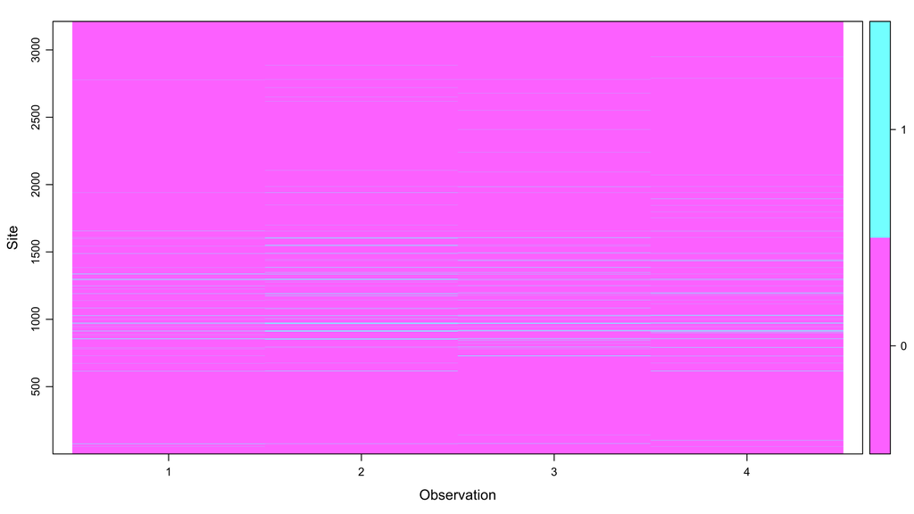

```r
plot(loup)
```

### 3. Mon premier modèle d’occupancy

Aide de la fonction `occu`.

```r
?occu
```

On spécifie la détection d’abord, puis l’occupancy. Ici ces paramètres sont constants.

```r
fm <- occu(~ 1 ~ 1, loup)
```

Les estimations sont sur l’échelle logit.

```r
fm
```

```
##
## Call:
## occu(formula = ~1 ~ 1, data = loup)
##
## Occupancy:
##  Estimate     SE     z   P(>|z|)
##     -2.71 0.0839 -32.2 6.74e-228
##
## Detection:
##  Estimate     SE     z  P(>|z|)
##    -0.499 0.0962 -5.19 2.15e-07
##
## AIC: 2236.609
```

On les back-transforme, c’est-à-dire qu’on obtient les estimations des probabilités entre 0 et 1.

```r
backTransform(fm, type ='state')
```

```
## Backtransformed linear combination(s) of Occupancy estimate(s)
##
##  Estimate      SE LinComb (Intercept)
##    0.0626 0.00493   -2.71           1
##
## Transformation: logistic
```

```r
backTransform(fm, type ='det')
```

```
## Backtransformed linear combination(s) of Detection estimate(s)
##
##  Estimate     SE LinComb (Intercept)
##     0.378 0.0226  -0.499           1
##
## Transformation: logistic
```

```r
confint(backTransform(fm, type='state'))
```

```
##       0.025      0.975
##  0.05364514 0.07302331
```

```r
confint(backTransform(fm, type='det'))
```

```
##      0.025     0.975
##  0.3346802 0.4230697
```

### 4. Et les covariables?

Ajoutons l’effort de prospection sur la détection, et la couverture forestière sur l’occupancy.

On refait le jeu de données.

```r
site.covs <- data.frame(effort = wolf_data %>% select(effort),
                        foret = wolf_data %>% select(foret))
loup <- unmarkedFrameOccu(y = wolf_data %>% select(occ1:occ4),
                          siteCovs = site.covs)
```

Données?

```r
summary(loup)
```

```
## unmarkedFrame Object
##
## 3211 sites
## Maximum number of observations per site: 4
## Mean number of observations per site: 4
## Sites with at least one detection: 171
##
## Tabulation of y observations:
##     0     1
## 12540   304
##
## Site-level covariates:
##      effort            foret
##  Min.   :-0.7836   Min.   :-1.25500
##  1st Qu.:-0.7026   1st Qu.:-0.92319
##  Median :-0.4190   Median :-0.09233
##  Mean   : 0.0000   Mean   : 0.00000
##  3rd Qu.: 0.3101   3rd Qu.: 0.75053
##  Max.   : 4.6039   Max.   : 3.02854
```

On ajuste modèle.

```r
fm1 <- occu(~ effort ~ foret, loup)
```

Les estimations.

```r
fm1
```

```
##
## Call:
## occu(formula = ~effort ~ foret, data = loup)
##
## Occupancy:
##             Estimate    SE     z  P(>|z|)
## (Intercept)   -1.231 0.161 -7.66 1.89e-14
## foret          0.643 0.113  5.70 1.21e-08
##
## Detection:
##             Estimate     SE     z  P(>|z|)
## (Intercept)    -3.17 0.1573 -20.2 2.20e-90
## effort          1.12 0.0648  17.2 1.67e-66
##
## AIC: 1946.236
```

Visualise.

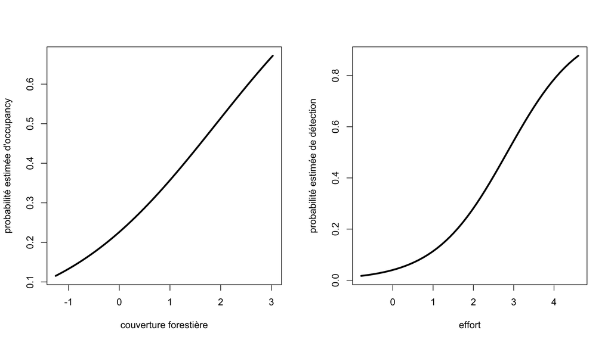

Il s’agit de variables qui dépendent uniquement du site. Et si on voulait mettre un effet du temps sur la détection?

On crée une variable pour l’effet du temps.

```r
temps <- matrix(c('tps 1','tps 2','tps 3', 'tps 4'),
              nrow = nrow(loup@y),
              ncol = ncol(loup@y),
              byrow = TRUE)
```

On refait le jeu de données.

```r
loup <- unmarkedFrameOccu(y = wolf_data %>% select(occ1:occ4),
                            siteCovs = site.covs,
                            obsCovs = list(temps = temps))
```

Données?

```r
summary(loup)
```

```
## unmarkedFrame Object
##
## 3211 sites
## Maximum number of observations per site: 4
## Mean number of observations per site: 4
## Sites with at least one detection: 171
##
## Tabulation of y observations:
##     0     1
## 12540   304
##
## Site-level covariates:
##      effort            foret
##  Min.   :-0.7836   Min.   :-1.25500
##  1st Qu.:-0.7026   1st Qu.:-0.92319
##  Median :-0.4190   Median :-0.09233
##  Mean   : 0.0000   Mean   : 0.00000
##  3rd Qu.: 0.3101   3rd Qu.: 0.75053
##  Max.   : 4.6039   Max.   : 3.02854
##
## Observation-level covariates:
##    temps
##  tps 1:3211
##  tps 2:3211
##  tps 3:3211
##  tps 4:3211
```

Ajuste le modèle avec effet temps sur la détection.

```r
fm2 <- occu(~ effort + temps ~ foret, loup)
```

On affiche les résultats.

```r
fm2
```

```
##
## Call:
## occu(formula = ~effort + temps ~ foret, data = loup)
##
## Occupancy:
##             Estimate    SE     z  P(>|z|)
## (Intercept)    -1.24 0.160 -7.72 1.13e-14
## foret           0.64 0.112  5.70 1.23e-08
##
## Detection:
##             Estimate     SE      z  P(>|z|)
## (Intercept)   -3.648 0.2161 -16.88 6.39e-64
## effort         1.128 0.0654  17.24 1.45e-66
## tempstps 2     0.781 0.2075   3.76 1.68e-04
## tempstps 3     0.585 0.2109   2.77 5.55e-03
## tempstps 4     0.429 0.2142   2.01 4.49e-02
##
## AIC: 1936.647
```

L’effet de la forêt est le même qu’on considère un effet du temps sur la détection ou pas. On visualise les effets de l’effort et du temps sur la détection.

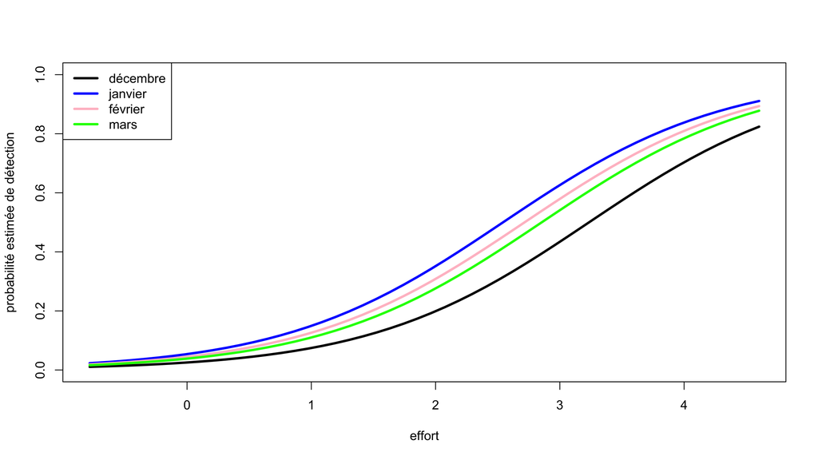

### 5. Sélection de modèles

On refait tourner les 3 modèles avec le même jeu de données.

```r
fm <- occu(~ 1 ~ 1, loup)
fm1 <- occu(~ effort ~ foret, loup)
fm2 <- occu(~ effort + temps ~ foret, loup)
```

On rassemble nos 3 modèles.

```r
fmList <- fitList('{psi, p}' = fm,
                  '{psi(foret), p(effort)}' = fm1,
                  '{psi(foret), p(effort + temps)}' = fm2)
```

Les AIC.

```r
modSel(fmList)
```

```
##                                 nPars     AIC  delta   AICwt cumltvWt
## {psi(foret), p(effort + temps)}     7 1936.65   0.00 9.9e-01     0.99
## {psi(foret), p(effort)}             4 1946.24   9.59 8.2e-03     1.00
## {psi, p}                            2 2236.61 299.96 7.3e-66     1.00
```